# Loading and cleaning data

Russell Dinnage and Anna Simonsen

First, we need to download the Werner et al. (2014) data set from Dryad if it is not already dowloaded, and then load it into R. We will also save a list of the species names from this dataset into the `data` directory of this package, so we can easily access it in other analyses.

```r
if (!file.exists("inst/extdata/Werner_NFix.csv")) {
    download.file("https://datadryad.org/bitstream/handle/10255/dryad.64120/Werner_NFix.csv",
        "inst/extdata/Werner_NFix.csv", "curl")
}
N_fix_data <- read.csv("inst/extdata/Werner_NFix.csv", stringsAsFactors = FALSE)
species <- N_fix_data$Species
legume_species <- N_fix_data$Species[N_fix_data$Family == "Fabaceae"]
other_species <- N_fix_data$Species[N_fix_data$Family != "Fabaceae"]
save(species, legume_species, other_species, file = "data/species.rda")
write.table(N_fix_data, file = "data/N_fix_data.csv", row.names = FALSE, sep = ";")
```

```
if [ ! -f ./data/gbif_occ.txt ]; then sed 's/\"//g' data/occurrence.txt > data/gbif_occ.txt; fi
```

First we will read in the first line and figure out what our columns are.

```r
library("LaF")
frow <- as.vector(read.table("bigdata/gbif_occ.txt", sep = "\t", nrows = 1,
    stringsAsFactors = FALSE)[1, ])
paste(frow, collapse = ", ")
```

```
[1] "gbifID, abstract, accessRights, accrualMethod, accrualPeriodicity, accrualPolicy, alternative, audience, available, bibliographicCitation, conformsTo, contributor, coverage, created, creator, date, dateAccepted, dateCopyrighted, dateSubmitted, description, educationLevel, extent, format, hasFor…
```

That is a lot of columns! `LaF` requires that you specify the type of all the columns, but we only care about a few of them. We will make sure these columns have the correct type. for the rest we will just import as ‘strings’. We are interested in the Species names, and the Latitudes, and the Longitudes. We will also use the GBIF ID column, in case we need to come back later an get additional data.

```r
col_type <- vector(mode = "character", length = length(frow))
names(col_type) <- as.character(frow)
col_need <- c("gbifID", "decimalLatitude", "decimalLongitude", "genus", "scientificName",
    "species", "family", "order", "speciesKey")
col_type[col_need] <- c("integer", "double", "double", "string", "string", "string",
    "string", "string", "integer")
col_type[col_type == ""] <- "string"
gbif_dat <- laf_open_csv("bigdata/gbif_occ.txt", column_types = col_type, column_names = as.character(frow),
    sep = "\t", skip = 1)
```

Now that the data is loaded using `LaF`, we can extract just the columns we want, which should be able to fit into memory (Only one way to find out for sure!).

```r
gbif_dat_reduced <- gbif_dat[, col_need]
## How big is it?
print(object.size(gbif_dat_reduced), units = "Mb")
```

```
933.1 Mb
```

As a basic sanity check, let’s load up some `dplyr` and `ggplot2` and see whether the data looks like it is actually data on a world map. But first we should reduce it so that we are only plotting the species which actually occur in the Werner et al. database of nitrogen fixation.

```r
library(dplyr)
library(ggplot2)
## convert to a dplyr table
gbif_dat_reduced <- gbif_dat_reduced %>% tbl_df
red <- gbif_dat_reduced %>% filter(gbif_dat_reduced$species %in% N_fix_data$Species)
red
```

```
Source: local data frame [11,115,875 x 9]

      gbifID decimalLatitude decimalLongitude      genus
1  891760516           34.81          -106.73 Desmanthus
2  891760536           43.55           -72.70     Betula
3  891760555           43.55           -72.70     Betula
4  891760558           34.67          -106.74 Desmanthus
5  891760572           44.26           -72.59      Fagus
6  891760574           44.26           -72.58     Betula
7  891760582           44.27           -72.58    Quercus
8  891760587           44.27           -72.58    Quercus
9  891760600           44.27           -72.58    Quercus
10 891760601           44.26           -72.59    Quercus
..       ...             ...              ...        ...
Variables not shown: scientificName (chr), species (chr), family (chr),
  order (chr), speciesKey (int)
```

Let’s plot it and see if it looks vaguely world shaped! (this might take awhile; we are plotting 11 million points!)

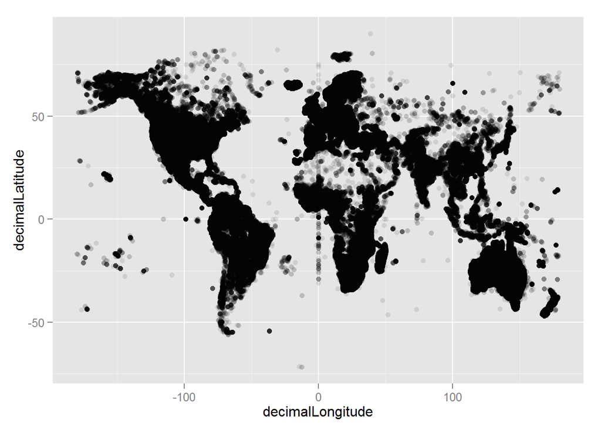

```r
p <- ggplot(red, aes(decimalLongitude, decimalLatitude)) + geom_point(alpha = 0.1)
p
```

Let’s see how many of the Werner et al. (2014) species have corresponding GBIF records.

```r
legumes_in_GBIF <- N_fix_data$Species[N_fix_data$Species %in% gbif_dat_reduced$species]
length(legumes_in_GBIF)
```

```
[1] 4535
```

So there are 4535 legumes that are in both the Werner et al. (2014) nitrogen fixation dataset and the GBIF spatial dataset. That is 49.5358%. How many of those were analysed in Werner et al. (2014) (which means they have a phylogeny and have been error checked)?

```r
fulldat_legumes <- sum(N_fix_data$Analysed_Werner_etal.[N_fix_data$Species %in%
    gbif_dat_reduced$species] == "Analysed")
fulldat_legumes
```

```
[1] 1635
```

So that is only 17.8591%. This is still a good number. But it suggests we may want to use the whole dataset, but conduct sensitivity analyses to see how are results are changed by simulating error in different ways. This might be a good place to use a “virtual ecologist” (Zurell et al. 2010) - style analysis, actually!

Let’s map out all the occurrences of species that were analysed in Werner et al. (2014).

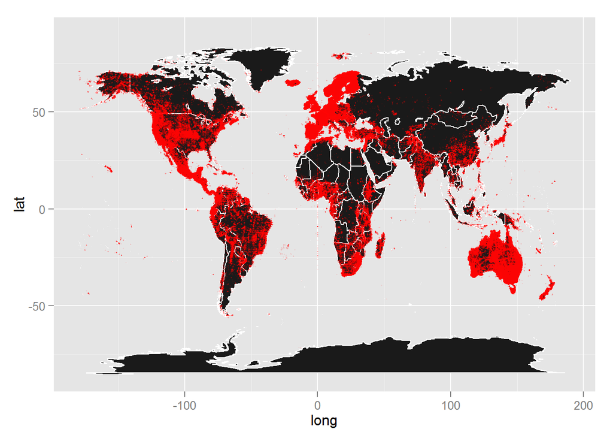

```r
library(maps)
reduced_data <- gbif_dat_reduced %>% filter(species %in% N_fix_data$Species[N_fix_data$Analysed_Werner_etal. ==
    "Analysed"])
all_states <- map_data("world")
# plot all states with ggplot
p <- ggplot()
p <- p + geom_polygon(data = all_states, aes(x = long, y = lat, group = group),
    colour = "white", fill = "grey10") + geom_point(data = reduced_data, aes(decimalLongitude,
    decimalLatitude), alpha = 0.1, colour = "red", size = 0.5)
p
```

The next step will be to look for and clean-up any obvious errors in the GBIF data. For example, there are a number of records at lat-long of exactly 0. This usually mean the data is missing and the recorders put zeroes instead of missing data for the coordinates. We will get rid of these. Also any records which are not on any land-masses (we are not interested in those pesky marine legumes in this study). We should also double-check that there are not any errors in the species names (there shouldn’t be).

For now, we will just remove the coordinates with exactly zero in the Latitude or Longitude, and remove the oceanic occurrences after we aggregate the data (because most of the points in the ocean will be just off-shore, suggesting they are just due to small errors. Then we will merge the GBIF data with the nitrogen fixation data and save it to our data directory for later use.

```r
library(GlobalNfix)
data(N_fix_data)  ## load data which is now part of GlobalNfix package
gbif_legumes <- gbif_dat_reduced %>% filter(gbif_dat_reduced$species %in% N_fix_data$Species) %>%
    filter(decimalLatitude != 0 & decimalLongitude != 0) %>% select(gbifID,
    decimalLatitude, decimalLongitude, genus, scientificName, Species = species,
    family, order, speciesKey)
full_legume_data <- left_join(gbif_legumes, N_fix_data)
full_legume_data %>% select(decimalLatitude, decimalLongitude, Species, Data_fixing)
```

```
Source: local data frame [4,851,732 x 4]

   decimalLatitude decimalLongitude                Species Data_fixing
1            34.81          -106.73 Desmanthus illinoensis         Yes
2            34.67          -106.74 Desmanthus illinoensis         Yes
3            28.72           -97.18            Dalea aurea         Yes
4            32.84           -93.92      Cercis canadensis          No
5            60.78          -148.84       Lupinus arcticus         Yes
6            44.51           -73.24  Hylodesmum glutinosum         Yes
7            37.46           -99.10   Tephrosia virginiana         Yes
8            37.46           -99.10         Dalea purpurea         Yes
9            37.45           -99.09            Dalea aurea         Yes
10           43.15           -85.56       Lupinus perennis         Yes
..             ...              ...                    ...         ...
```

```r
save(full_legume_data, file = "data/full_legume_data.rda")
```

Map of full data (including legume species not analysed in Werner et al. (2014)):

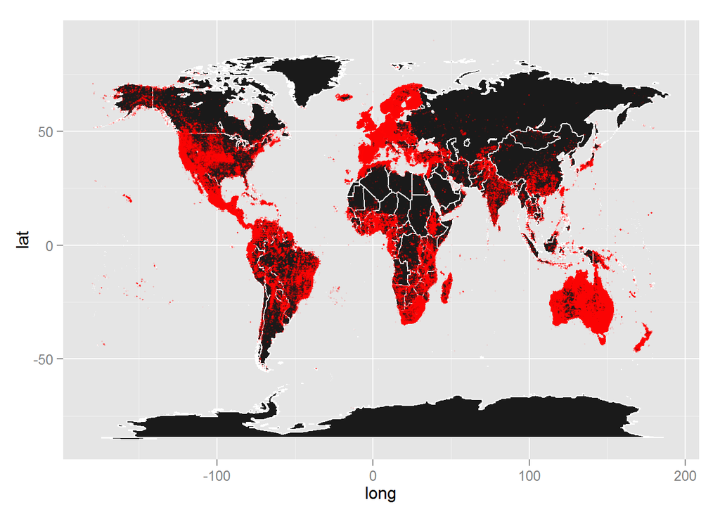

```r
p <- ggplot()
p <- p + geom_polygon(data = all_states, aes(x = long, y = lat, group = group),
    colour = "white", fill = "grey10") + geom_point(data = full_legume_data,
    aes(decimalLongitude, decimalLatitude), alpha = 0.1, colour = "red", size = 0.5)
p
```

References

Werner, Gijsbert D A, William K Cornwell, Janet I Sprent, Jens Kattge, and E Toby Kiers. 2014. “A Single Evolutionary Innovation Drives the Deep Evolution of Symbiotic N2-Fixation in Angiosperms.” *Nature Communications* 5 (January): 4087. doi:10.1038/ncomms5087. http://www.nature.com/ncomms/2014/140610/ncomms5087/full/ncomms5087.html.

Zurell, Damaris, Uta Berger, Juliano S. Cabral, Florian Jeltsch, Christine N. Meynard, Tamara M??nkem??ller, Nana Nehrbass, et al. 2010. “The Virtual Ecologist Approach: Simulating Data and Observers.” *Oikos* 119 (4): 622–635.